# Thousand Droplets in a Dried Pool

### **Thousand Droplets in a Dried Pool**

#### December 04, 2017 Unemployment Youth Selection test

Late in July, the [Congolese government has launched young professional program that aims to recruit a thousand candidates to work in the public administration](https://www.radiookapi.net/offre-demploi/sodeico-1000-jeunes-universitaires-pour-la-fonction-publique). The eligibility is tailored to propel only candidates those hold a bachelor’s degree, are within 35 years-old and have Congolese nationality. This project is piggybacked by the [World Bank](http://www.worldbank.org/) grant that ensures some budgets for the occupational integration of youth in the employment market; and it’s run by [Sodeico](http://sodeico.org/sodeicoWP2016/), a local recruitment agency. This last oversees job applications, the screening process, and selection tests.

Last weekend, [a friend of mine](https://twitter.com/Richy_Zola) shared on social media the list of shortlisted candidates for the passage of the selection tests. Given that it does not require any credential to open it, I did so. I was shocked by the number of retained people, `24,526` in total, knowing that only `1,000` positions are available. Below the split into regions:

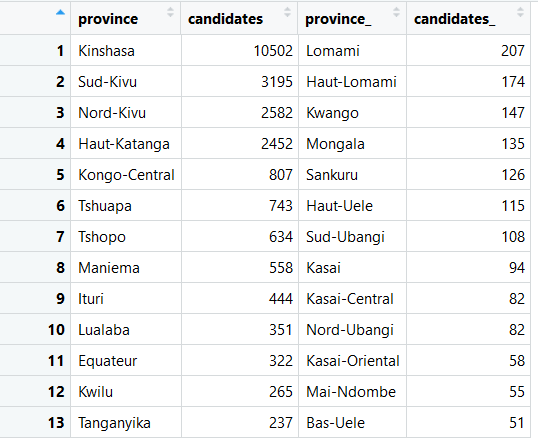

Here, the graphical representation of the table above:

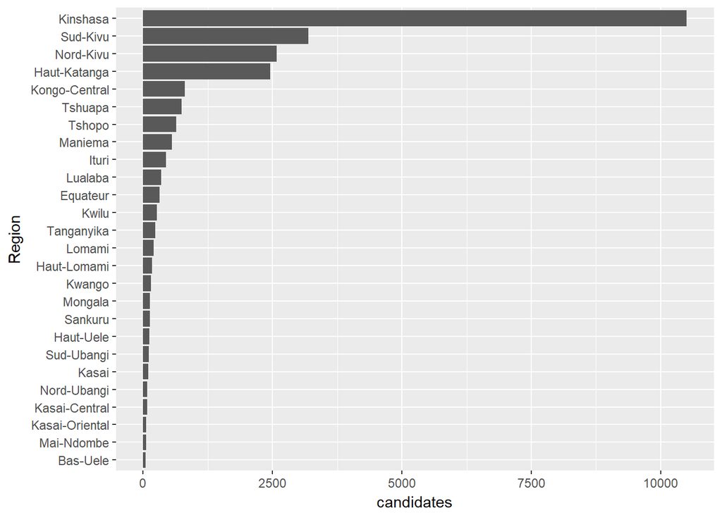

After the completion of all steps, the Ministry of Public Service will merely hire `4.1%` of the shortlisted candidates, and `95.9%` will just be stuck in the mud of unemployment that became a curse in the country. While referring to the list above, some regions are represented by a minuscule number of candidates that the government can directly hire without relying on some sponsoring of the World Bank.

If the government keeps the same quota for upcoming years, candidates who are `35` will no longer be eligible next year. After two years, the `34-years-old` guys will be also affected by that recruitment restriction, and so forth. However, at this pace, most people may stay jobless for life. Owing to this, they have to sprint faster than everyone to seize this opportunity.

[figure not shown]

Thousand vacancies across the country are not enough to cover the unemployment pool—the country must invest in the youth for a sustainable future and for accelerating its development.